# Экзаменационная работа

Елена Вакуленко

28 июня 2018

# 1. Выбираем набор данных

Подключаем пакеты

```r
library(tidyverse)
library(rio)
library(skimr)
library(lattice)
library(DataExplorer)
library(corrplot) # визуализация корреляций

library(cluster) # кластерный анализ
library(factoextra) # визуализации kmeans, pca,
library(dendextend) # визуализация дендрограмм

library(broom) # метла превращает результаты оценивания моделей в таблички

library(naniar) # визуализация пропущенных значений
library(visdat) # визуализация пропущенных значений

library(patchwork) # удобное расположение графиков рядом

library(GGally) # больше готовых графиков
library(sjPlot) # ещё больше графиков
library(lmtest) # диагностика линейных моделей
library(Ecdat) # много-много разных наборов данных
library(sjstats) # удобные мелкие функции для работы с моделями
library(sandwich) # оценка Var для гетероскедастичности
library(AER) # работа с инструментальными переменными

library(caret) # пакет для подбора параметров разных моделей
library(FFTrees) # быстрые деревья
library(margins) # для подсчёта предельных эффектов
library(rpart.plot) # для картинок деревьев
library(plotROC) # визуализация ROC-кривой
library(ggeffects) # графики для предельных эффектов
library(MLmetrics) # метрики качества
library(ranger) # строим деревья
library(factoextra) # графики для кластеризации и pca
library(elasticnet) # LASSO
library(latex2exp) # формулы в подписях к графику
library(distances) # расчет различных расстояний
```

# 2. Загружаем данные формата Excel. Проводим описательный анализ данных.

```r
setwd("~/GitHub/r_course/data")
mig <- import('migration.xls')
glimpse(mig)
```

```
## Observations: 78
## Variables: 10
## $ region         <chr> "Белгородская область", "Брянская область", "Вл...
## $ net_mig_all    <dbl> 5.7703850, -4.4029740, -0.7031137, 3.3899830, -...
## $ pop_density    <dbl> 56.497380, 36.664090, 49.683670, 44.737240, 49....
## $ gdp            <dbl> 361923.0, 146760.0, 213446.0, 331940.0, 101535....
## $ u              <dbl> 5.2, 8.0, 6.2, 7.5, 7.6, 6.5, 6.2, 8.2, 4.5, 3....
## $ lnincome_pmini <dbl> 1.2598850, 0.9916663, 0.7662650, 0.8869036, 0.7...
## $ oil_gas_gdp    <dbl> 16.8, 0.1, 0.4, 0.5, 0.2, 0.4, 0.1, 12.1, 0.8, ...
## $ geography      <chr> "west", "west", "west", "west", "west", "west",...
## $ resources      <chr> "yes", "no", "no", "no", "no", "no", "no", "yes...
## $ migration      <chr> "positive", "negative", "negative", "positive",...
```

```r
head(mig)
```

```
##                 region net_mig_all pop_density    gdp   u lnincome_pmini
## 1 Белгородская область   5.7703850    56.49738 361923 5.2      1.2598850
## 2     Брянская область  -4.4029740    36.66409 146760 8.0      0.9916663
## 3 Владимирская область  -0.7031137    49.68367 213446 6.2      0.7662650
## 4  Воронежская область   3.3899830    44.73724 331940 7.5      0.8869036
## 5   Ивановская область  -0.2128057    49.54052 101535 7.6      0.7022964
## 6    Калужская область  -1.7292490    33.98596 177297 6.5      1.0712240
##   oil_gas_gdp geography resources migration
## 1        16.8      west       yes  positive
## 2         0.1      west        no  negative
## 3         0.4      west        no  negative
## 4         0.5      west        no  positive
## 5         0.2      west        no  negative
## 6         0.4      west        no  negative
```

```r
tail(mig)
```

```
##                          region net_mig_all pop_density      gdp   u
## 73             Амурская область   -8.850422   2.2906060 166697.0 6.9
## 74              Камчатский край   -7.500000   0.6935545 112840.0 7.1
## 75          Магаданская область  -24.592360   0.3394859  54161.4 5.7
## 76          Сахалинская область  -12.811240   5.7175000 438287.0 9.3
## 77 Еврейская автономная область   -7.193182   4.8530300  29500.6 9.4
## 78          Чукотский авт.округ  -34.294120   0.0706879  48003.6 4.1
##    lnincome_pmini oil_gas_gdp geography resources migration
## 73      0.6746895        10.2      east       yes  negative
## 74      0.7860386         4.1      east        no  negative
## 75      1.0906770        20.6      east       yes  negative
## 76      1.2299850        59.3      east       yes  negative
## 77      0.8146752         0.3      east        no  negative
## 78      1.2279150        38.2      east       yes  negative
```

```r
skim(mig)
```

```
## Skim summary statistics
##  n obs: 78
##  n variables: 10
##
## Variable type: character
##   variable missing complete  n min max empty n_unique
##  geography       0       78 78   4   4     0        2
##  migration       0       78 78   8   8     0        2
##     region       0       78 78   8  33     0       78
##  resources       0       78 78   2   3     0        2
##
## Variable type: numeric
##        variable missing complete  n      mean       sd        p0       p25
##             gdp       0       78 78 446259.75 9e+05    24589.6   127298
##  lnincome_pmini       0       78 78      0.98     0.21     0.42       0.87
##     net_mig_all       0       78 78     -3.44     7.84   -34.29      -6.84
##     oil_gas_gdp       0       78 78      8.1     12.84     0          0.3
##     pop_density       0       78 78    206.19  1247.93     0.071      5.55
##               u       0       78 78      8.24     2.82     1.7        6.62
##        p50       p75       p100     hist
##  232283.5  434159.75 7300000    ▇▁▁▁▁▁▁▁
##       0.97      1.09       1.62 ▁▁▃▇▃▂▁▁
##      -2.93      0.26      16.18 ▁▁▁▂▇▇▂▁
##       1.1      12.05      59.3  ▇▁▁▁▁▁▁▁
##      22.63     42.31   10540.79 ▇▁▁▁▁▁▁▁
##       8         9.28      22    ▁▃▇▂▁▁▁▁
```

```r
mig<- mutate(mig, geography = factor(geography), migration = factor(migration), resources = factor(resources))
#Другой способ
#mig <- mutate_if(mig, is.character, factor)
skim(mig)
```

```
## Skim summary statistics
##  n obs: 78
##  n variables: 10
##
## Variable type: character
##  variable missing complete  n min max empty n_unique
##    region       0       78 78   8  33     0       78
##
## Variable type: factor
##   variable missing complete  n n_unique              top_counts ordered
##  geography       0       78 78        2 wes: 52, eas: 26, NA: 0   FALSE
##  migration       0       78 78        2 neg: 57, pos: 21, NA: 0   FALSE
##  resources       0       78 78        2  no: 56, yes: 22, NA: 0   FALSE
##
## Variable type: numeric
##        variable missing complete  n      mean       sd        p0       p25
##             gdp       0       78 78 446259.75 9e+05    24589.6   127298
##  lnincome_pmini       0       78 78      0.98     0.21     0.42       0.87
##     net_mig_all       0       78 78     -3.44     7.84   -34.29      -6.84
##     oil_gas_gdp       0       78 78      8.1     12.84     0          0.3
##     pop_density       0       78 78    206.19  1247.93     0.071      5.55
##               u       0       78 78      8.24     2.82     1.7        6.62
##        p50       p75       p100     hist
##  232283.5  434159.75 7300000    ▇▁▁▁▁▁▁▁
##       0.97      1.09       1.62 ▁▁▃▇▃▂▁▁
##      -2.93      0.26      16.18 ▁▁▁▂▇▇▂▁
##       1.1      12.05      59.3  ▇▁▁▁▁▁▁▁
##      22.63     42.31   10540.79 ▇▁▁▁▁▁▁▁
##       8         9.28      22    ▁▃▇▂▁▁▁▁
```

2.3. Построим гистрограммы для количественных и качественных переменных и диаграммы рассеивания для количественных.

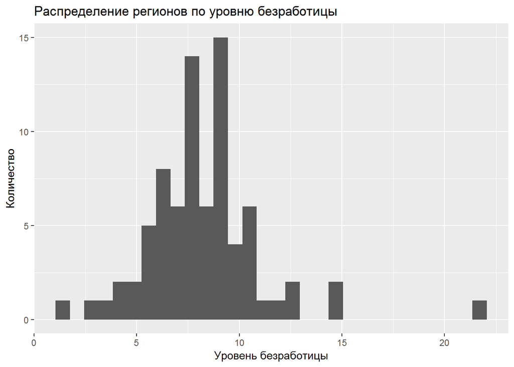

```r
qplot(data = mig, x = u) +
  labs(x = 'Уровень безработицы', y = 'Количество', title = 'Распределение регионов по уровню безработицы')
```

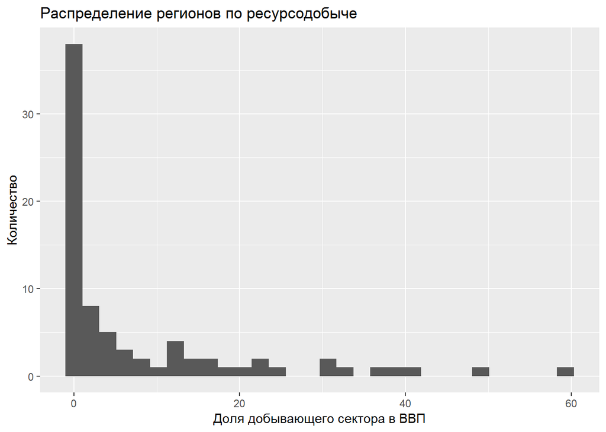

```r
qplot(data = mig, x = oil_gas_gdp)  +
  labs(x = 'Доля добывающего сектора в ВВП', y = 'Количество', title = 'Распределение регионов по ресурсодобыче')
```

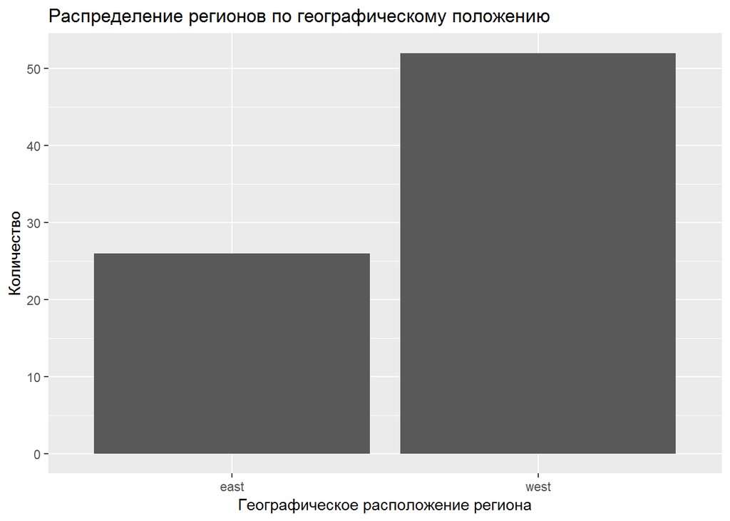

```r
qplot(data = mig, x = geography)  +
  labs(x = 'Географическое расположение региона', y = 'Количество', title = 'Распределение регионов по географическому положению')
```

Диаграммы рассеивания

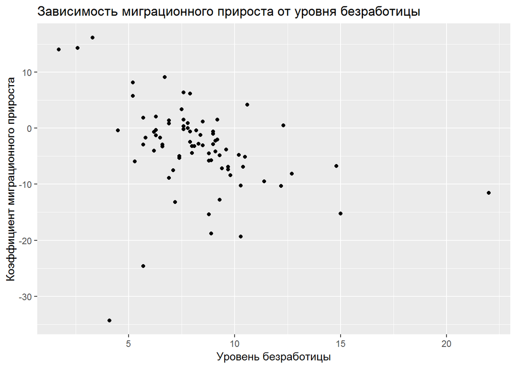

```r
qplot(data = mig, x = u, y = net_mig_all) +
  labs(x = 'Уровень безработицы', y = 'Коэффициент миграционного прироста', title = 'Зависимость миграционного прироста от уровня безработицы')
```

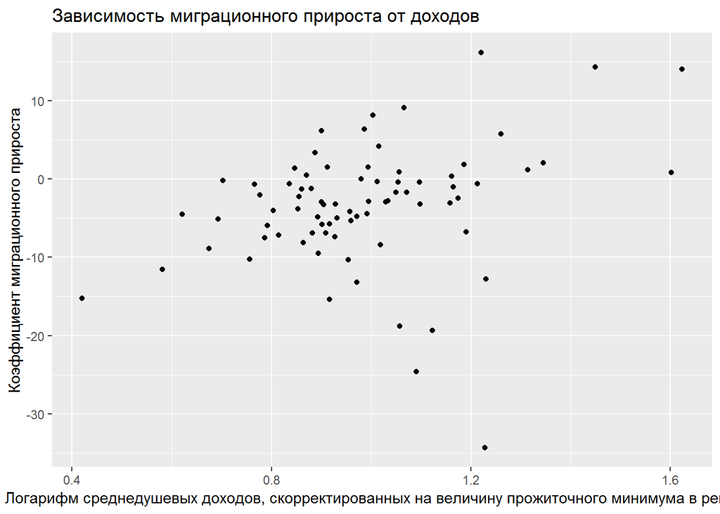

```r
qplot(data = mig, x = lnincome_pmini, y = net_mig_all) +
  labs(x = 'Логарифм среднедушевых доходов, скорректированных на величину прожиточного минимума в регионе', y = 'Коэффициент миграционного прироста', title = 'Зависимость миграционного прироста от доходов')
```

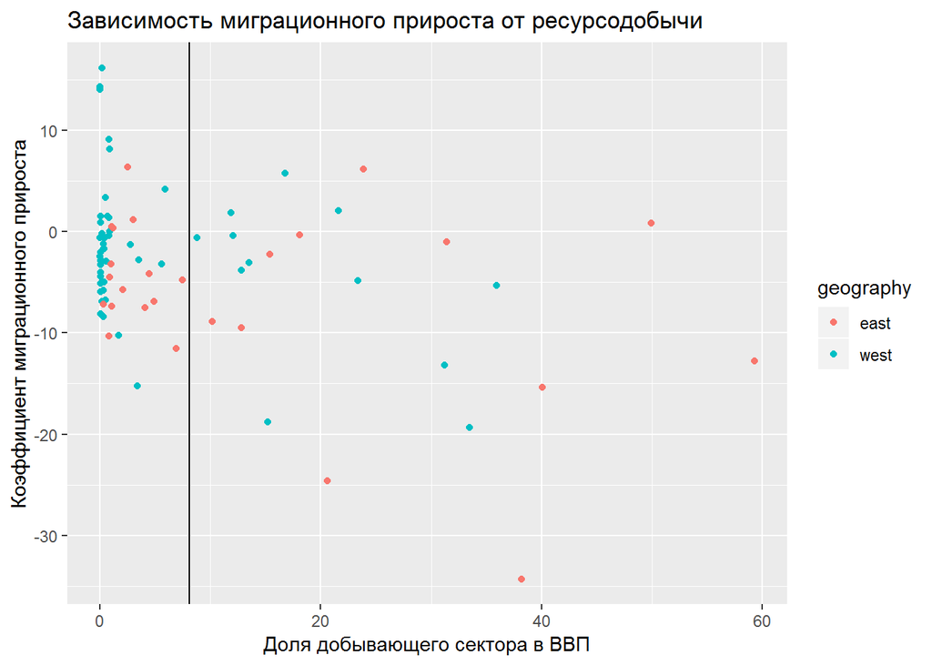

```r
ggplot(data = mig) +
  geom_point(aes(x = oil_gas_gdp, y = net_mig_all, color = geography)) +
  geom_vline(aes(xintercept = mean(oil_gas_gdp))) +
  labs(x = 'Доля добывающего сектора в ВВП', y = 'Коэффициент миграционного прироста', title = 'Зависимость миграционного прироста от ресурсодобычи')
```

Отберем количественные переменные и рассчитаем корреляции

```r
mig2 <- select(mig, net_mig_all:oil_gas_gdp)
mig_cor <- cor(mig2)
mig_cor
```

```
##                net_mig_all pop_density         gdp          u
## net_mig_all      1.0000000  0.33465248  0.42737634 -0.3693868
## pop_density      0.3346525  1.00000000  0.88357322 -0.3297032
## gdp              0.4273763  0.88357322  1.00000000 -0.3867615
## u               -0.3693868 -0.32970316 -0.38676146  1.0000000
## lnincome_pmini   0.2935701  0.42552450  0.61498448 -0.4792206
## oil_gas_gdp     -0.3857701 -0.09861818  0.09045755 -0.0261426
##                lnincome_pmini oil_gas_gdp
## net_mig_all         0.2935701 -0.38577009
## pop_density         0.4255245 -0.09861818
## gdp                 0.6149845  0.09045755
## u                  -0.4792206 -0.02614260
## lnincome_pmini      1.0000000  0.32552074
## oil_gas_gdp         0.3255207  1.00000000
```

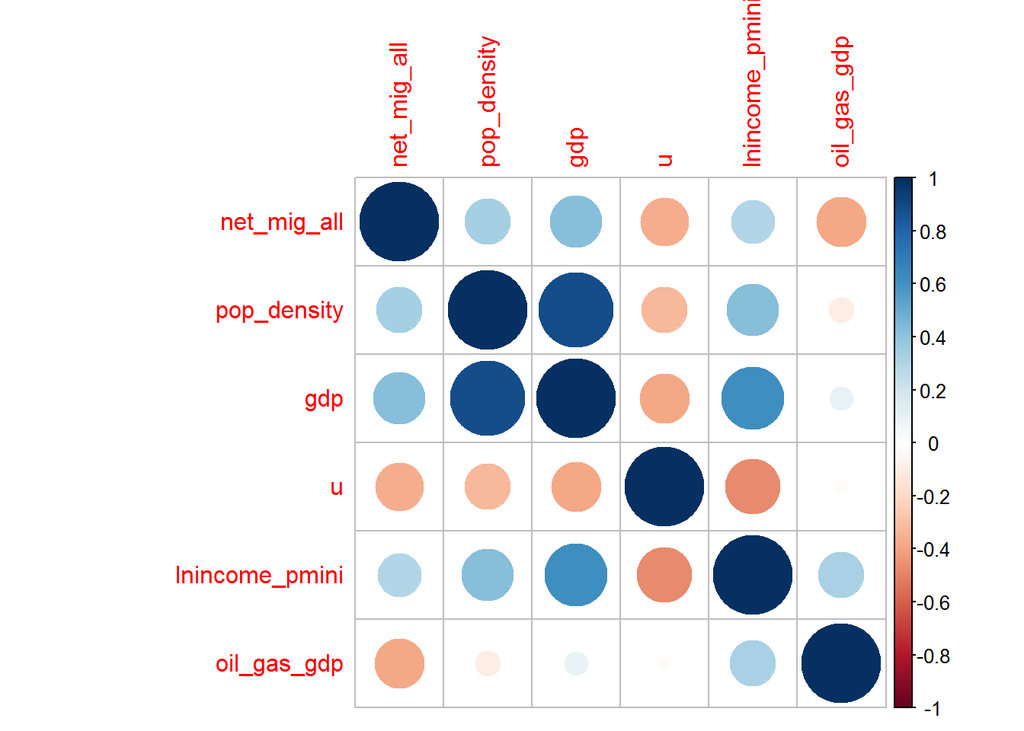

```r
corrplot(mig_cor) # график с аргументами по умолчанию
```

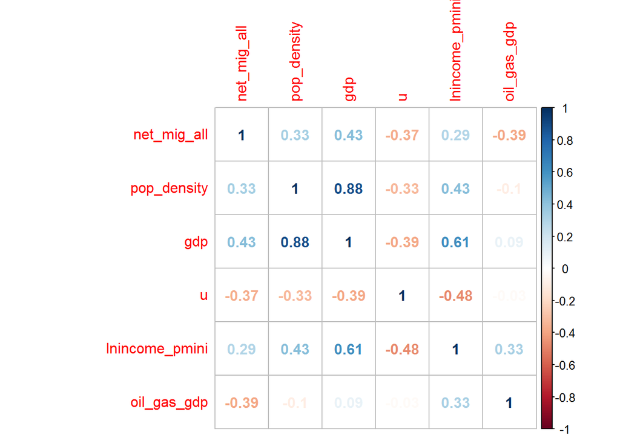

```r
corrplot(mig_cor, method = 'number') # график со значениями корреляции
```

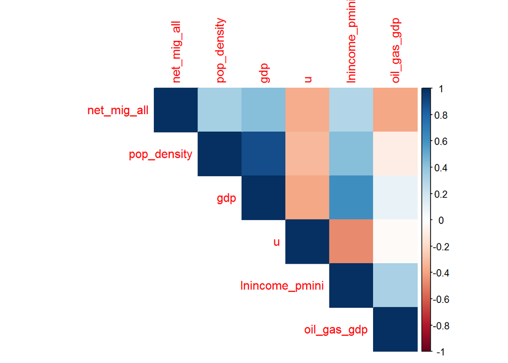

```r
corrplot(mig_cor, method = 'color', type = 'upper') # только правая верхняя часть
```

# 3. Проведение кластеризации данных методом k-средних

Отмасштабируем все числовые переменные с помощью функции `scale()`.

```r
mig3 <- mig2 %>%
  mutate_if(is.numeric, ~ as.vector(scale(.)))
```

3.1. Определим оптимальное число кластеров. Один из способов сделать это — воспользоваться командой `fviz_nbclust` из пакета `factoextra`.

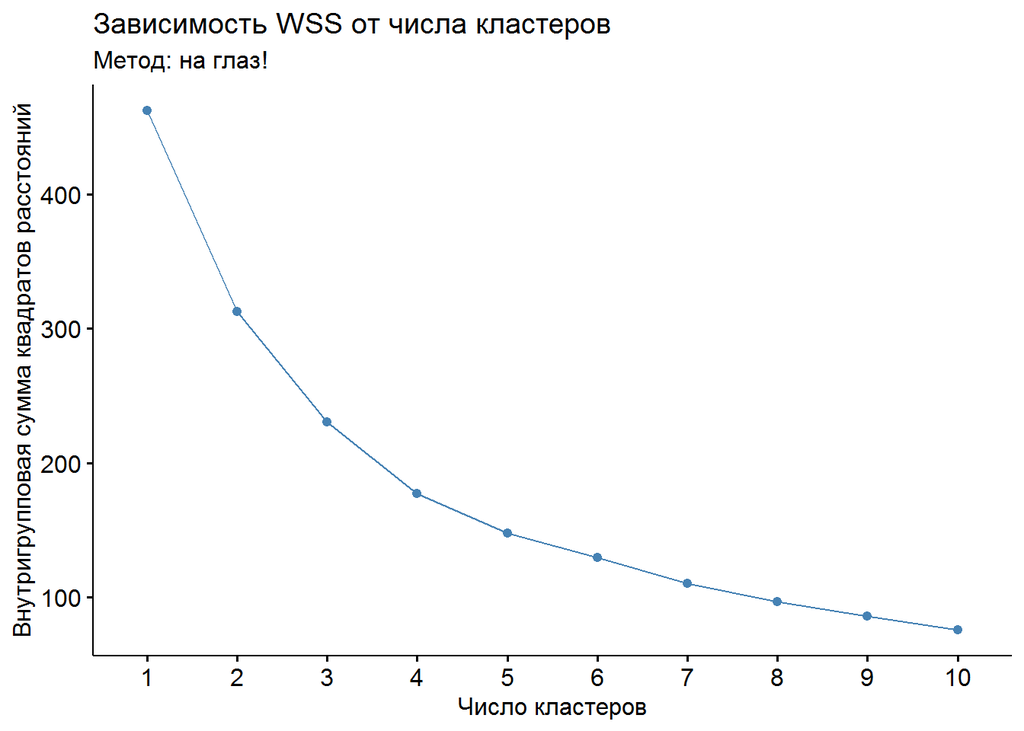

```r
g1 <- fviz_nbclust(mig3, kmeans, method = 'wss') +
  labs(title = 'Зависимость WSS от числа кластеров',
       subtitle = 'Метод: на глаз!', x = 'Число кластеров',
       y = 'Внутригрупповая сумма квадратов расстояний')
g1
```

По методу “на глаз” стоит выбрать 2 кластера.

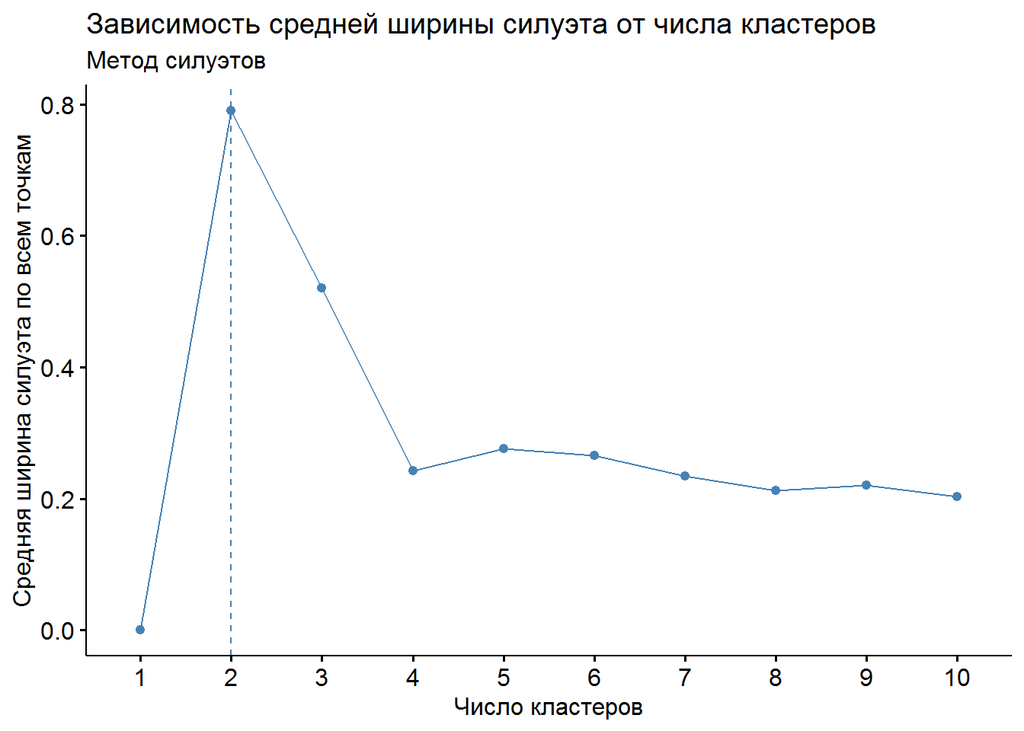

```r
g2 <- fviz_nbclust(mig3, kmeans, method = 'silhouette') +
  labs(subtitle = 'Метод силуэтов',
       title = 'Зависимость средней ширины силуэта от числа кластеров',
       y = 'Средняя ширина силуэта по всем точкам',
       x = 'Число кластеров')
g2
```

По данному методу наилучшее число кластеров также равно двум.

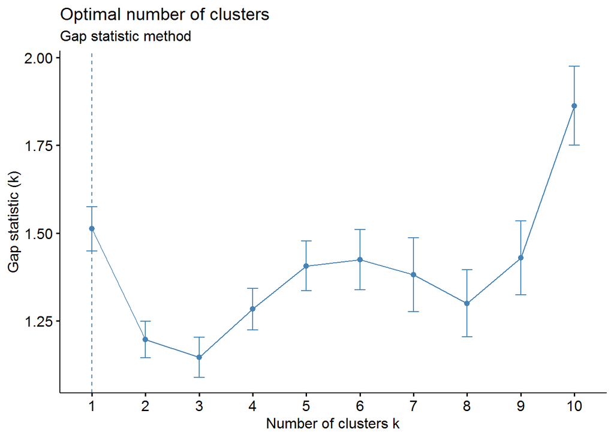

```r
g3 <- fviz_nbclust(mig2, kmeans, method = 'gap_stat') +
  labs(subtitle = 'Gap statistic method')
g3
```

По gap statistics оптимальное число кластеров равно 1, т.к. это первое число, после которого статистика резко падает.

В результате выберем 2 кластера.

```r
set.seed(15)
k_means_mig <- kmeans(mig2, centers = 2)
k_means_mig
```

```
## K-means clustering with 2 clusters of sizes 1, 77
##
## Cluster means:
##   net_mig_all pop_density       gdp        u lnincome_pmini oil_gas_gdp
## 1   14.012000 10540.79000 7300000.0 1.700000      1.6231150    0.000000
## 2   -3.662635    71.97709  357250.1 8.325974      0.9764403    8.209091
##
## Clustering vector:
##  [1] 2 2 2 2 2 2 2 2 2 2 2 2 2 2 2 2 2 1 2 2 2 2 2 2 2 2 2 2 2 2 2 2 2 2 2
## [36] 2 2 2 2 2 2 2 2 2 2 2 2 2 2 2 2 2 2 2 2 2 2 2 2 2 2 2 2 2 2 2 2 2 2 2
## [71] 2 2 2 2 2 2 2 2
##
## Within cluster sum of squares by cluster:
## [1] 0.000000e+00 1.441141e+13
##  (between_SS / total_SS =  76.8 %)
##
## Available components:
##
## [1] "cluster"      "centers"      "totss"        "withinss"
## [5] "tot.withinss" "betweenss"    "size"         "iter"
## [9] "ifault"
```

Оказывается, что процедура кластеризации выделяет отдельно регион 18, т.е. Москву. Требуется проводить кластеризацию без Москвы.

Узнаем величину WSS с разбивкой по кластерам:

```r
k_means_mig$withinss
```

```
## [1] 0.000000e+00 1.441141e+13
```

Межгрупповая сумма квадратов расстояний, BSS (between):

```r
k_means_mig$betweenss
```

```
## [1] 4.758391e+13
```

Общая сумма квадратов расстояний, TSS (total):

```r
k_means_mig$totss
```

```
## [1] 6.199532e+13
```

# Иерархическая кластеризация

```r
mig_dist <- dist(mig2, method = 'euclidian')
```

Расстояния тоже можно визуализировать! Сделаем это командой `fviz_dist` из пакета `factoextra`.

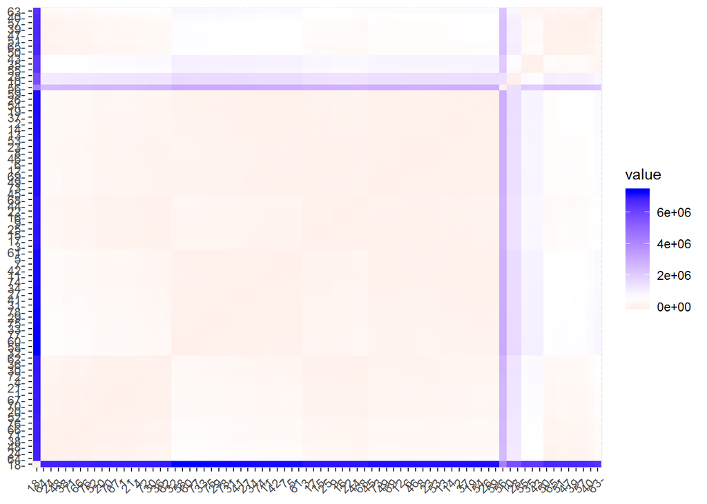

```r
fviz_dist(mig_dist)
```

Полученную матрицу расстояний можно передадать функции `hclust()`, которая кластеризует данные. Однако в пакете `factoextra` есть функция `hcut()`, которая работает с исходными данными. Будем использовать её и попросим выделить четыре кластера в аргументе `k`.

```r
mig_hcl <- hcut(mig2, k = 4,
                    hc_metric = 'euclidean', hc_method = 'ward.D2')
```

С помощью функции `fviz_dend` визуализируем результат кластеризации. Укажем несколько аргументов, чтобы сделать дендрограмму красивее.

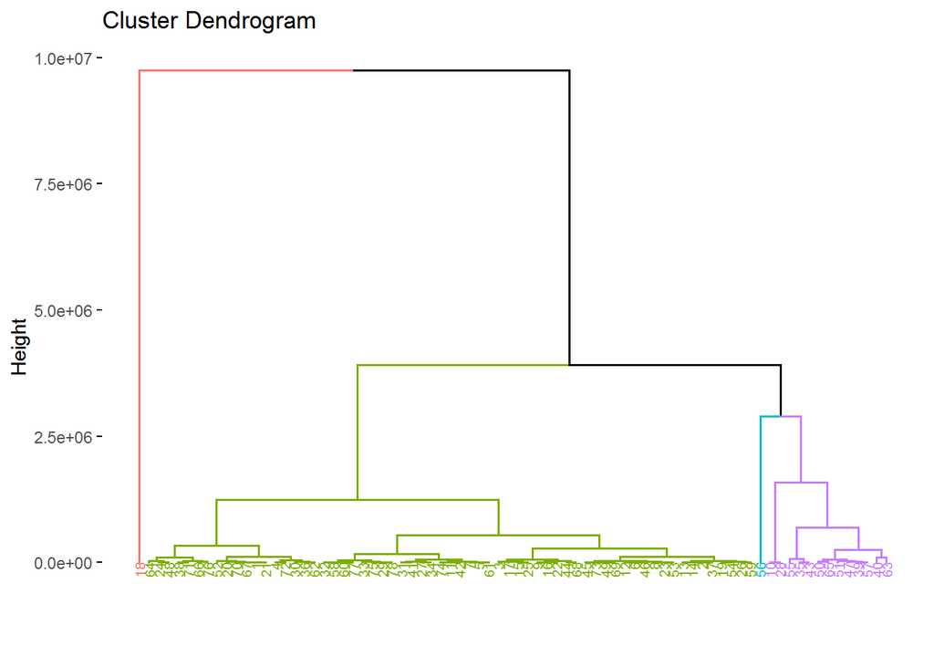

```r
fviz_dend(mig_hcl,
          cex = 0.5, # размер подписи
          color_labels_by_k = TRUE) # цвет подписей по группам
```

Выявленные кластеры можно добавить к исходным данным!

```r
mig_plus2 <- mutate(mig2, cluster = mig_hcl$cluster)
glimpse(mig_plus2)
```

```
## Observations: 78
## Variables: 7
## $ net_mig_all    <dbl> 5.7703850, -4.4029740, -0.7031137, 3.3899830, -...
## $ pop_density    <dbl> 56.497380, 36.664090, 49.683670, 44.737240, 49....
## $ gdp            <dbl> 361923.0, 146760.0, 213446.0, 331940.0, 101535....
## $ u              <dbl> 5.2, 8.0, 6.2, 7.5, 7.6, 6.5, 6.2, 8.2, 4.5, 3....
## $ lnincome_pmini <dbl> 1.2598850, 0.9916663, 0.7662650, 0.8869036, 0.7...
## $ oil_gas_gdp    <dbl> 16.8, 0.1, 0.4, 0.5, 0.2, 0.4, 0.1, 12.1, 0.8, ...
## $ cluster        <int> 1, 1, 1, 1, 1, 1, 1, 1, 1, 2, 1, 1, 1, 1, 1, 1,...
```

# Метод главных компонент

Построим главные компонены по нашему набору данных количесвенных переменных.

```r
mig_pca <- prcomp(mig2, scale. = TRUE)
mig_pca
```

```
## Standard deviations (1, .., p=6):
## [1] 1.6926091 1.1810706 0.9213381 0.7139730 0.5602344 0.2601203
##
## Rotation (n x k) = (6 x 6):
##                         PC1         PC2         PC3         PC4        PC5
## net_mig_all    -0.355027134  0.48581767 -0.30020978  0.58885788 -0.4169169
## pop_density    -0.487981245  0.07085428  0.53115236 -0.29482661 -0.0552334
## gdp            -0.539287121 -0.06426870  0.37158501  0.02064174 -0.1463401
## u               0.382980088  0.02457764  0.66166242  0.62912980  0.1315379
## lnincome_pmini -0.445225525 -0.34820331 -0.22261942  0.36545756  0.6957019
## oil_gas_gdp    -0.009996194 -0.79560090 -0.04815878  0.19113881 -0.5480975
##                        PC6
## net_mig_all    -0.16503861
## pop_density    -0.62028839
## gdp             0.73832379
## u              -0.04264404
## lnincome_pmini -0.11579681
## oil_gas_gdp    -0.16629836
```

Посмотрим, что лежит в этом списке.

```r
attributes(mig_pca)
```

```
## $names
## [1] "sdev"     "rotation" "center"   "scale"    "x"
##
## $class
## [1] "prcomp"
```

Сами новые искусственные главные компоненты лежат в матрице `protein_pca$x`. Например, первая главная компонента:

```r
mig_pca$x[, 1]
```

```
##  [1]  -1.32489244   0.24851876   0.28043997  -0.05960399   0.65475401
##  [6]  -0.26656874   0.43567610  -0.07502516  -0.70058747  -2.73935496
## [11]   0.33169313   0.38818431   0.33066173  -0.24932380   0.15624085
## [16]  -0.36773254  -0.13021689 -11.21863354   0.75804229   0.82038119
## [21]   0.44042877   0.35143449   0.12696409  -0.91809690   0.83019973
## [26]  -0.19477419   0.87647075  -4.54114028   0.36681757   0.75317846
## [31]   1.36064981   3.01483971   1.39970513   0.63150522  -1.22706155
## [36]   0.05170724   0.12728086   0.16923290  -0.24236382  -0.60789178
## [41]   1.31497674   0.40966954  -1.57740002   0.57528426   0.75063411
## [46]   0.60902739  -0.44255074   0.05944664   0.17915666  -0.37886627
## [51]  -1.08576240   0.02520109   0.57184302   1.19081431  -1.11232172
## [56]  -3.20485807  -0.67769738   0.95936385   0.88393658   3.44601930
## [61]   0.62489838   1.08033976  -0.61041670   0.40333819  -0.42932467
## [66]  -0.45876480  -0.14404034  -0.12181066   1.14498006   0.87440172
## [71]   0.60333998   0.36486055   0.98227312   0.74428442   0.68928012
## [76]   0.07923060   1.03205185   0.60342251
```

Выборочные стандартные отклонения компонент (корни из $\lambda_j$) лежат в векторе `mig_pca$sdev`:

```r
mig_pca$sdev
```

```
## [1] 1.6926091 1.1810706 0.9213381 0.7139730 0.5602344 0.2601203
```

Матрица `mig_pca$rotation` содержит веса, с которыми исходные переменные входят в новые искуственные главные компоненты. Например, в первой главной компоненте лежат исходные переменные с весами:

```r
mig_pca$rotation[, 1]
```

```
##    net_mig_all    pop_density            gdp              u lnincome_pmini
##   -0.355027134   -0.487981245   -0.539287121    0.382980088   -0.445225525
##    oil_gas_gdp
##   -0.009996194
```

3.2. Визуализируем данные в осях первых двух главных компонент. Для этого воспользуемся функцией `fviz_pca_ind()` из пакета `factoextra`. Рисовать будем `mig_pca`, а аргумент `repel = TRUE` укажем для того, чтобы подписи на графике не перекрывали друг друга.

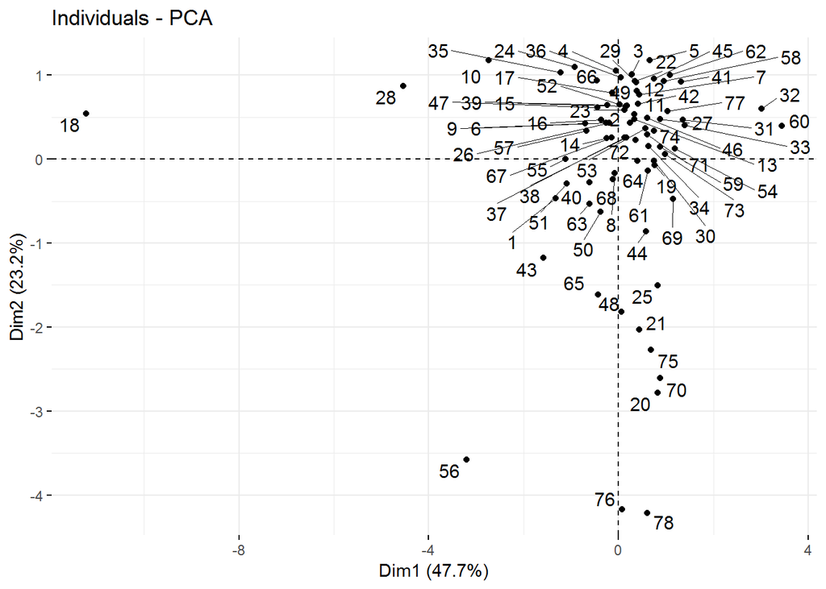

```r
fviz_pca_ind(mig_pca, repel = TRUE)
```

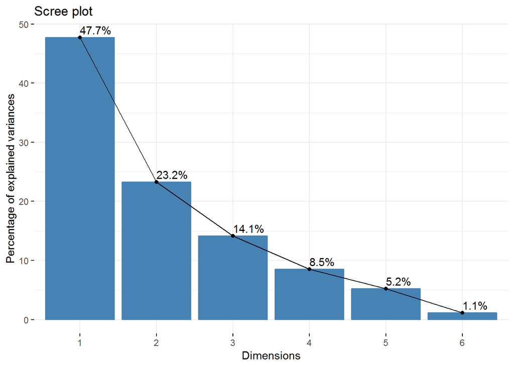

```r
fviz_eig(mig_pca, addlabels = TRUE)
```

3.3. На первую главную компоненту приходится около 48%, на вторую - 23% объясненной дисперсии. Такие регионы, как 18 (Москва), 78 (Чукотка), 56 (Тюменская область), 76 (Сахалинская область) сильно отличаются от всех остальных.В основном все регионы концентрируются в области положильных значений обеих компонент.

В осях первых двух главных компонент исходные данные можно раскрасить согласно кластерам:

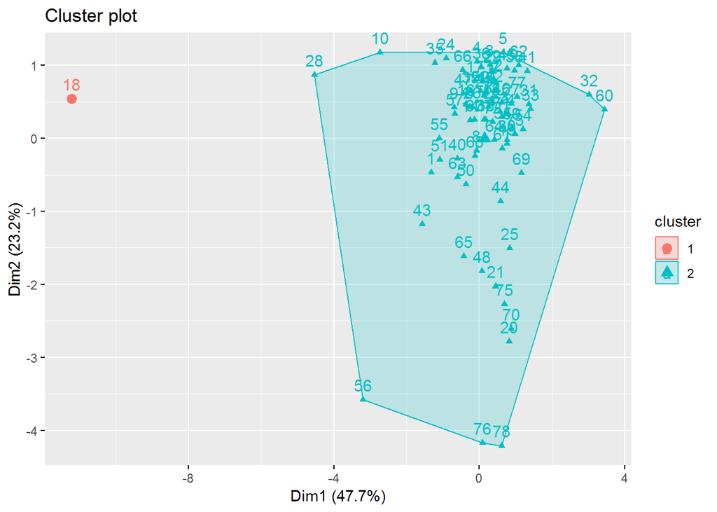

```r
fviz_cluster(object = k_means_mig,
             data = mig3,
             ellipse.type = 'convex')
```

Отдельная красная точка соответствует Москве. Попробуем увеличить количество кластеров до 3-х и изобразить результат.

```r
set.seed(15)
k_means_mig2 <- kmeans(mig2, centers = 3)
k_means_mig2
```

```
## K-means clustering with 3 clusters of sizes 1, 6, 71
##
## Cluster means:
##   net_mig_all pop_density       gdp        u lnincome_pmini oil_gas_gdp
## 1   14.012000 10540.79000 7300000.0 1.700000       1.623115    0.000000
## 2    7.292519   628.39868 1523676.5 5.716667       1.332722   12.583333
## 3   -4.588422    24.95555  258678.9 8.546479       0.946332    7.839437
##
## Clustering vector:
##  [1] 3 3 3 3 3 3 3 3 3 2 3 3 3 3 3 3 3 1 3 3 3 3 3 3 3 3 3 2 3 3 3 3 3 3 2
## [36] 3 3 3 3 3 3 3 2 3 3 3 3 3 3 3 3 3 3 3 2 2 3 3 3 3 3 3 3 3 3 3 3 3 3 3
## [71] 3 3 3 3 3 3 3 3
##
## Within cluster sum of squares by cluster:
## [1] 0.000000e+00 3.077944e+12 2.480305e+12
##  (between_SS / total_SS =  91.0 %)
##
## Available components:
##
## [1] "cluster"      "centers"      "totss"        "withinss"
## [5] "tot.withinss" "betweenss"    "size"         "iter"
## [9] "ifault"
```

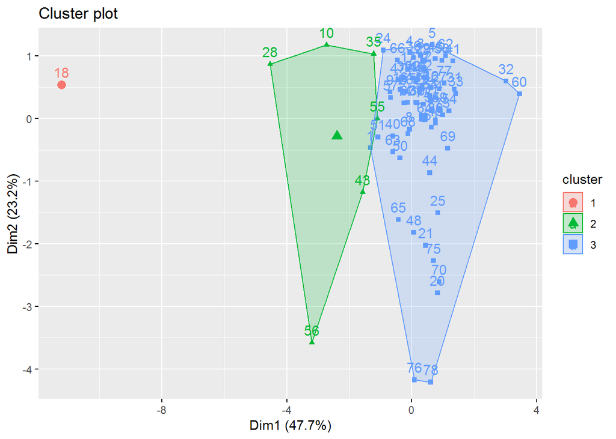

```r
fviz_cluster(object = k_means_mig2,
             data = mig3,
             ellipse.type = 'convex')
```

На графиках видно, что такое разбиение более адекватное. Как и прежде отделяется Москва (точка 18), а все остальные регионы разбиваются на два кластера.

# 4. Оценим модель линейной регрессии

Начнем с короткой модели. Зависимая переменная - коэффициент миграционного прироста. Объясняюшие переменные: уровень безработицы, среднедушевые доходы, % добывающего сектора в ВРП.

```r
model_r <- lm(data = mig, net_mig_all ~ u + lnincome_pmini + oil_gas_gdp)
```

С помощью команды `summary()` посмотрим на описание модели.

```r
summary(model_r)
```

```
##
## Call:
## lm(formula = net_mig_all ~ u + lnincome_pmini + oil_gas_gdp,
##     data = mig)
##
## Residuals:
##      Min       1Q   Median       3Q      Max
## -27.2829  -3.0107  -0.1969   3.7392  15.4858
##
## Coefficients:
##                Estimate Std. Error t value Pr(>|t|)
## (Intercept)    -9.54274    5.71194  -1.671  0.09901 .
## u              -0.58756    0.29387  -1.999  0.04924 *
## lnincome_pmini 13.67052    4.27174   3.200  0.00202 **
## oil_gas_gdp    -0.31010    0.05992  -5.175 1.89e-06 ***
## ---
## Signif. codes:  0 '***' 0.001 '**' 0.01 '*' 0.05 '.' 0.1 ' ' 1
##
## Residual standard error: 6.303 on 74 degrees of freedom
## Multiple R-squared:  0.3789, Adjusted R-squared:  0.3537
## F-statistic: 15.05 on 3 and 74 DF,  p-value: 9.701e-08
```

```r
glance(model_r)
```

```
##   r.squared adj.r.squared    sigma statistic      p.value df    logLik
## 1 0.3788776      0.353697 6.302926  15.04639 9.700837e-08  4 -252.2232
##        AIC      BIC deviance df.residual
## 1 514.4464 526.2299 2939.789          74
```

Оценим длинную модель линейной регрессии, добавив плотность населения и дамми переменную на географическое положение.

```r
model_ur <- lm(data = mig, net_mig_all ~ u + lnincome_pmini + oil_gas_gdp +
pop_density + geography)
summary(model_ur)
```

```
##
## Call:
## lm(formula = net_mig_all ~ u + lnincome_pmini + oil_gas_gdp +
##     pop_density + geography, data = mig)
##
## Residuals:
##     Min      1Q  Median      3Q     Max
## -26.620  -2.788  -0.042   3.643  15.764
##
## Coefficients:
##                  Estimate Std. Error t value Pr(>|t|)
## (Intercept)    -9.5924112  6.1150190  -1.569   0.1211
## u              -0.5213912  0.3043762  -1.713   0.0910 .
## lnincome_pmini 12.1577556  4.6755520   2.600   0.0113 *
## oil_gas_gdp    -0.2846369  0.0658227  -4.324 4.84e-05 ***
## pop_density     0.0005317  0.0006715   0.792   0.4310
## geographywest   1.0171019  1.6613757   0.612   0.5423
## ---
## Signif. codes:  0 '***' 0.001 '**' 0.01 '*' 0.05 '.' 0.1 ' ' 1
##
## Residual standard error: 6.346 on 72 degrees of freedom
## Multiple R-squared:  0.3874, Adjusted R-squared:  0.3448
## F-statistic: 9.105 on 5 and 72 DF,  p-value: 9.6e-07
```

```r
glance(model_ur)
```

```
##   r.squared adj.r.squared    sigma statistic     p.value df    logLik
## 1 0.3873545     0.3448097 6.346114   9.10462 9.59951e-07  6 -251.6873
##        AIC      BIC deviance df.residual
## 1 517.3745 533.8715 2899.668          72
```

Дополнительные переменные оказались незначимыми на любом разумном уровне значимости.

Проведем диагностику модели.

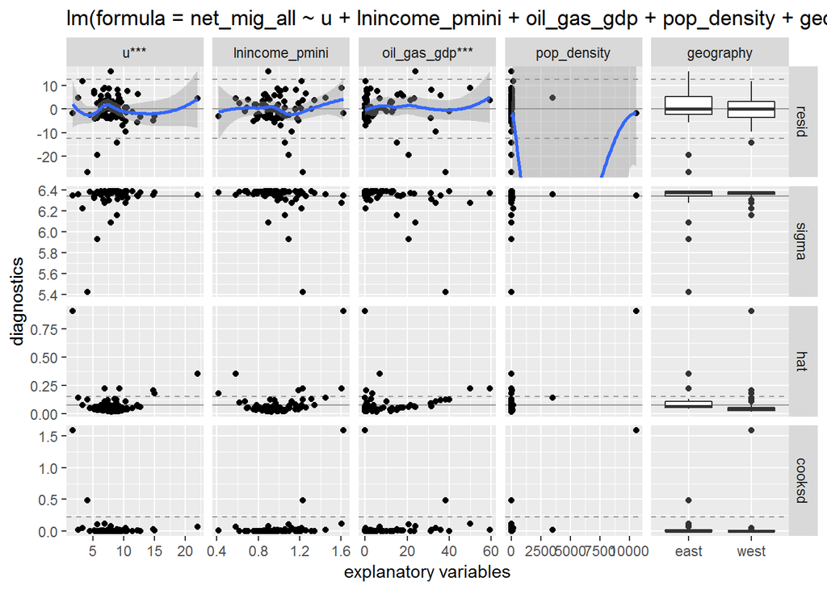

```r
ggnostic(model = model_ur)
```

В модели явно есть выбросы, что мы уже отмечали ранее.

Расмотрим коэффициенты модели и их доверительные интервалы:

```r
coefci(model_ur)
```

```
##                        2.5 %       97.5 %
## (Intercept)    -2.178248e+01  2.597656328
## u              -1.128154e+00  0.085371665
## lnincome_pmini  2.837213e+00 21.478298139
## oil_gas_gdp    -4.158521e-01 -0.153421757
## pop_density    -8.068045e-04  0.001870278
## geographywest  -2.294790e+00  4.328993851
```

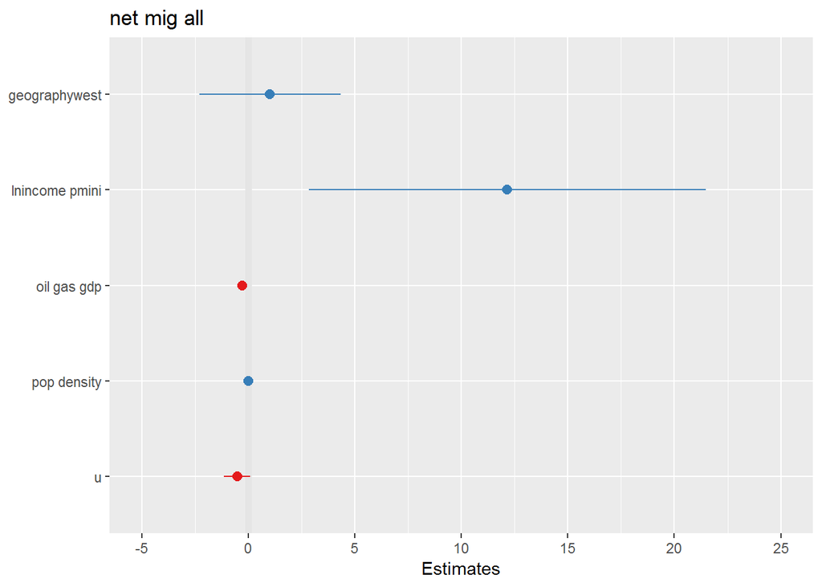

```r
plot_model(model_ur, ci.lvl = 0.95)
```

Сравним длинную и короткую модели.Если есть две вложенных модели, то есть одна является частным случаем другой, то можно провести тест Вальда, чтобы выбрать одну из них.

$H_0$: верна ограниченная (короткая) модель;

$H_a$: верная неограниченная (длинная) модель;

```r
waldtest(model_r, model_ur)
```

```
## Wald test
##
## Model 1: net_mig_all ~ u + lnincome_pmini + oil_gas_gdp
## Model 2: net_mig_all ~ u + lnincome_pmini + oil_gas_gdp + pop_density +
##     geography
##   Res.Df Df      F Pr(>F)
## 1     74
## 2     72  2 0.4981 0.6098
```

p-value теста Вальда больше любого разумного уровня значимости, нулевая гипотеза не отвергается. Отдаем предпочтение короткой модели. Дополнительно включенные факторы оказываются совместно незначимыми.

Оценим регрессии в случае гетероскедастичных ошибок.

```r
coeftest(model_ur, vcov. = vcovHC)
```

```
##
## t test of coefficients:
##
##                   Estimate  Std. Error t value Pr(>|t|)
## (Intercept)    -9.59241124  6.51735599 -1.4718 0.145426
## u              -0.52139120  0.41299616 -1.2625 0.210857
## lnincome_pmini 12.15775562  4.06556896  2.9904 0.003811 **
## oil_gas_gdp    -0.28463691  0.08728200 -3.2611 0.001697 **
## pop_density     0.00053174  0.00188110  0.2827 0.778238
## geographywest   1.01710195  1.89049818  0.5380 0.592231
## ---
## Signif. codes:  0 '***' 0.001 '**' 0.01 '*' 0.05 '.' 0.1 ' ' 1
```

```r
coeftest(model_r, vcov. = vcovHC)
```

```
##
## t test of coefficients:
##
##                 Estimate Std. Error t value  Pr(>|t|)
## (Intercept)    -9.542741   5.396659 -1.7683 0.0811376 .
## u              -0.587561   0.368154 -1.5960 0.1147590
## lnincome_pmini 13.670515   3.488887  3.9183 0.0001971 ***
## oil_gas_gdp    -0.310096   0.097576 -3.1780 0.0021648 **
## ---
## Signif. codes:  0 '***' 0.001 '**' 0.01 '*' 0.05 '.' 0.1 ' ' 1
```

Коэффициент при уровне безработицы стал незначимым даже на 10% уровне значимости.

Получим доверительные интервалы:

```r
coefci(model_ur, vcov. = vcovHC)
```

```
##                        2.5 %      97.5 %
## (Intercept)    -22.584522964  3.39970048
## u               -1.344684003  0.30190161
## lnincome_pmini   4.053192012 20.26231923
## oil_gas_gdp     -0.458630393 -0.11064344
## pop_density     -0.003218166  0.00428164
## geographywest   -2.751537288  4.78574118
```

```r
coefci(model_r, vcov. = vcovHC)
```

```
##                      2.5 %     97.5 %
## (Intercept)    -20.2958201  1.2103371
## u               -1.3211238  0.1460024
## lnincome_pmini   6.7187559 20.6222750
## oil_gas_gdp     -0.5045208 -0.1156717
```

Дополнительные регрессоры также незначимы.

Сравним две вложенных модели с учётом поправки на гетероскедастичность:

```r
waldtest(model_r, model_ur, vcov = vcovHC)
```

```
## Wald test
##
## Model 1: net_mig_all ~ u + lnincome_pmini + oil_gas_gdp
## Model 2: net_mig_all ~ u + lnincome_pmini + oil_gas_gdp + pop_density +
##     geography
##   Res.Df Df      F Pr(>F)
## 1     74
## 2     72  2 0.1814 0.8345
```

Результаты теста качественно неизменились. Отдаем предпочтение короткой модели.

# 5. Проведем задачу классификации.

```r
mig <- mutate(mig, migration = factor(migration))

skim(mig)
```

```
## Skim summary statistics
##  n obs: 78
##  n variables: 10
##
## Variable type: character
##  variable missing complete  n min max empty n_unique
##    region       0       78 78   8  33     0       78
##
## Variable type: factor
##   variable missing complete  n n_unique              top_counts ordered
##  geography       0       78 78        2 wes: 52, eas: 26, NA: 0   FALSE
##  migration       0       78 78        2 neg: 57, pos: 21, NA: 0   FALSE
##  resources       0       78 78        2  no: 56, yes: 22, NA: 0   FALSE
##
## Variable type: numeric
##        variable missing complete  n      mean       sd        p0       p25
##             gdp       0       78 78 446259.75 9e+05    24589.6   127298
##  lnincome_pmini       0       78 78      0.98     0.21     0.42       0.87
##     net_mig_all       0       78 78     -3.44     7.84   -34.29      -6.84
##     oil_gas_gdp       0       78 78      8.1     12.84     0          0.3
##     pop_density       0       78 78    206.19  1247.93     0.071      5.55
##               u       0       78 78      8.24     2.82     1.7        6.62
##        p50       p75       p100     hist
##  232283.5  434159.75 7300000    ▇▁▁▁▁▁▁▁
##       0.97      1.09       1.62 ▁▁▃▇▃▂▁▁
##      -2.93      0.26      16.18 ▁▁▁▂▇▇▂▁
##       1.1      12.05      59.3  ▇▁▁▁▁▁▁▁
##      22.63     42.31   10540.79 ▇▁▁▁▁▁▁▁
##       8         9.28      22    ▁▃▇▂▁▁▁▁
```

Создадим вектор `mig_rows` с номерами строк для обучающей части. Возьмем 70% от общей выборки.

```r
set.seed(555)
mig_rows <- createDataPartition(mig$migration, p = 0.7, list = FALSE)
```

И разделим выборку согласно вектору `mig_rows`:

```r
mig_train <- mig[mig_rows, ]
mig_test <- mig[-mig_rows, ]
```

# Логистическая регрессия

С помощью метода максимального правдоподобия оценивается модель

$$y_i =
\begin{cases}
1, \text{ если } y^*_i \geq 0; \\
0, \text{ иначе.}
\end{cases}$$

$$y_i^* = \beta_1 + \beta_2 x_i + \beta_3 z_i + u_i,$$
где $u_i$ имеет специальное логистическое распределение.

Также модель можно записать в виде:

$$\frac{\ln P(y_i = 1)}{\ln P(y_i = 0)} = \beta_1 + \beta_2 x_i + \beta_3 z_i$$

Реализуем логистическую регрессию с помощью функции `glm`. Передадим ей набор данных `mig_train`, формулу и укажем специальный аргумент `family = binomial(link = 'logit')`. Сохраним результаты оценивания в переменную `mig_lmodel` и посмотрим на них. Зависимая переменная - положительный или отрицательный миграционный прирост. Объясняющие переменные те, которые были в длинной линейной регрессионной модели.

```r
mig_lmodel_glm <- glm(data = mig_train, migration ~ u + lnincome_pmini + oil_gas_gdp + geography + pop_density, family = binomial(link = 'logit'))
summary(mig_lmodel_glm)
```

```
##
## Call:
## glm(formula = migration ~ u + lnincome_pmini + oil_gas_gdp +
##     geography + pop_density, family = binomial(link = "logit"),
##     data = mig_train)
##
## Deviance Residuals:
##     Min       1Q   Median       3Q      Max
## -1.7280  -0.5622  -0.2741   0.2167   2.2243
##
## Coefficients:
##                Estimate Std. Error z value Pr(>|z|)
## (Intercept)    -8.43424    4.37570  -1.928   0.0539 .
## u              -0.07697    0.21841  -0.352   0.7245
## lnincome_pmini  8.01586    3.66959   2.184   0.0289 *
## oil_gas_gdp    -0.09861    0.07001  -1.408   0.1590
## geographywest  -1.75170    1.22887  -1.425   0.1540
## pop_density     0.05756    0.02628   2.190   0.0285 *
## ---
## Signif. codes:  0 '***' 0.001 '**' 0.01 '*' 0.05 '.' 0.1 ' ' 1
##
## (Dispersion parameter for binomial family taken to be 1)
##
##     Null deviance: 64.455  on 54  degrees of freedom
## Residual deviance: 39.645  on 49  degrees of freedom
## AIC: 51.645
##
## Number of Fisher Scoring iterations: 6
```

Значимыми оказались только переменные доходов и плотности населения, причем на 5% уровне значимости.

Чтобы найти предельные эффекты, воспользуемся функцией `margins` из одноимённого пакета. Снова выведем результаты командой `summary()`.

```r
mig_margins <- margins(mig_lmodel_glm)
summary(mig_margins)
```

```
##          factor     AME     SE       z      p   lower  upper
##   geographywest -0.1989 0.1262 -1.5760 0.1150 -0.4463 0.0485
##  lnincome_pmini  0.9112 0.3531  2.5808 0.0099  0.2192 1.6032
##     oil_gas_gdp -0.0112 0.0076 -1.4700 0.1416 -0.0262 0.0037
##     pop_density  0.0065 0.0024  2.7039 0.0069  0.0018 0.0113
##               u -0.0087 0.0247 -0.3543 0.7231 -0.0572 0.0397
```

```r
pred_mig_vis <- ggpredict(mig_lmodel_glm, terms = c('lnincome_pmini', 'geography'), pretty = FALSE)

plot(pred_mig_vis)
```

[output not shown]

Оценивать логистическую модель также можно с помощью пакета `caret`. Изменения минимальные:

```r
mig_lmodel <- train(data = mig_train, migration ~ u + lnincome_pmini + oil_gas_gdp + geography + pop_density, family = binomial(link = 'logit'), method = 'glm')
summary(mig_lmodel)
```

```
##
## Call:
## NULL
##
## Deviance Residuals:
##     Min       1Q   Median       3Q      Max
## -1.7280  -0.5622  -0.2741   0.2167   2.2243
##
## Coefficients:
##                Estimate Std. Error z value Pr(>|z|)
## (Intercept)    -8.43424    4.37570  -1.928   0.0539 .
## u              -0.07697    0.21841  -0.352   0.7245
## lnincome_pmini  8.01586    3.66959   2.184   0.0289 *
## oil_gas_gdp    -0.09861    0.07001  -1.408   0.1590
## geographywest  -1.75170    1.22887  -1.425   0.1540
## pop_density     0.05756    0.02628   2.190   0.0285 *
## ---
## Signif. codes:  0 '***' 0.001 '**' 0.01 '*' 0.05 '.' 0.1 ' ' 1
##
## (Dispersion parameter for binomial family taken to be 1)
##
##     Null deviance: 64.455  on 54  degrees of freedom
## Residual deviance: 39.645  on 49  degrees of freedom
## AIC: 51.645
##
## Number of Fisher Scoring iterations: 6
```

Построим прогнозы модели для тестовых данных `mig_test`. Для этого будем использовать функцию `predict`, которой передадим оценённую модель `mig_lmodel`. В переменной `mig_pred` уже будут лежать предсказанные классы. Чтобы получить их вероятности, нужно добавить аргумент `type = 'prob'`.

```r
mig_pred <- predict(mig_lmodel, newdata = mig_test)
head(mig_pred)
```

```
## [1] negative negative negative positive negative negative
## Levels: negative positive
```

```r
mig_prob <- predict(mig_lmodel, newdata = mig_test, type = 'prob')
head(mig_prob)
```

```
##        negative   positive
## 2  6.796371e-01 0.32036289
## 6  5.455400e-01 0.45445996
## 15 9.257720e-01 0.07422805
## 18 2.220446e-16 1.00000000
## 22 9.736943e-01 0.02630570
## 25 9.728237e-01 0.02717634
```

Теперь мы можем посмотреть на матрицу ошибок и узнать, насколько хорошую модель мы оценили. Для этого будем использовать функцию `confusionMatrix` из пакета `caret`. В качестве аргумента `data` нужно указать предсказанные значения, а в `reference` — правильные ответы.

```r
confusionMatrix(data = mig_pred, reference = mig_test$migration)
```

```
## Confusion Matrix and Statistics
##
##           Reference
## Prediction negative positive
##   negative       14        4
##   positive        3        2
##
##                Accuracy : 0.6957
##                  95% CI : (0.4708, 0.8679)
##     No Information Rate : 0.7391
##     P-Value [Acc > NIR] : 0.7675
##
##                   Kappa : 0.1658
##  Mcnemar's Test P-Value : 1.0000
##
##             Sensitivity : 0.8235
##             Specificity : 0.3333
##          Pos Pred Value : 0.7778
##          Neg Pred Value : 0.4000
##              Prevalence : 0.7391
##          Detection Rate : 0.6087
##    Detection Prevalence : 0.7826
##       Balanced Accuracy : 0.5784
##
##        'Positive' Class : negative
##
```

Процент правильно предсказанных значений равен 69.5%. Чувствительность - 82.3%, специфичность - 33.3%.

Создадим столбцы с вероятностями классов под названиями самих этих классов, истинные ответы под названием `obs`, и бинарные предсказания, названные как `pred`. Поэтому создадим отдельную таблицу `mig_test_set` со всеми результатами оценивания.

```r
mig_test_set <- data.frame(positive = mig_prob$positive,
                        negative = mig_prob$negative,
                        pred = mig_pred,
                        obs = mig_test$migration)
glimpse(mig_test_set)
```

```
## Observations: 23
## Variables: 4
## $ positive <dbl> 0.32036289, 0.45445996, 0.07422805, 1.00000000, 0.026...
## $ negative <dbl> 6.796371e-01, 5.455400e-01, 9.257720e-01, 2.220446e-1...
## $ pred     <fct> negative, negative, negative, positive, negative, neg...
## $ obs      <fct> negative, negative, negative, positive, negative, neg...
```

```r
twoClassSummary(mig_test_set, lev = levels(mig_test_set$obs)) # don't work with tibble
```

```
##       ROC      Sens      Spec
## 0.6764706 0.8235294 0.3333333
```

```r
prSummary(mig_test_set, lev = levels(mig_test_set$obs)) # нужен пакет MLmetrics
```

```
##       AUC Precision    Recall         F
## 0.7569879 0.7777778 0.8235294 0.8000000
```

Построим ROC-кривую. Для этого вдобавок к базовому cлою `ggplot` мы будем использовать слой `geom_roc` из пакета `plotROC`. В эстетиках нужно указать аргументы `d` — истинные значения — и `m` — метки класса 1. Если добавить аргумент `color`, то можно получить разные ROC-кривые по географическому положению регионов, например.

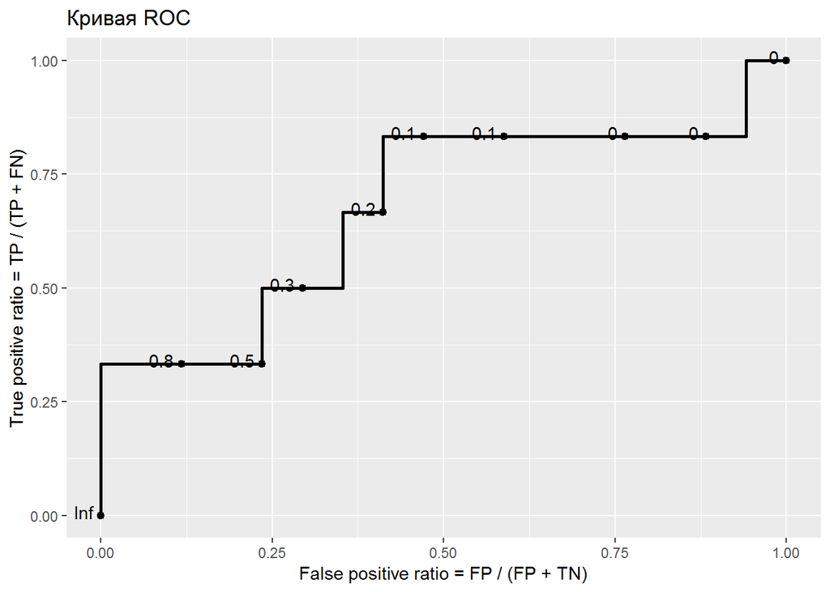

```r
ggplot(mig_test_set, aes(d = obs, m = positive)) +
  geom_roc(n.cuts = 10) +
  labs(title = 'Кривая ROC',
       x = 'False positive ratio = FP / (FP + TN)',
       y = 'True positive ratio = TP / (TP + FN)')
```

[figure not shown]

```r
mig_test_set <- mutate(mig_test_set, geo = mig_test$geography)

ggplot(mig_test_set, aes(d = obs, m = positive, color = geo)) +
  geom_roc(n.cuts = 0) +
  labs(title = 'Кривые ROC в зависимости от ресурсов',
       x = 'False positive ratio = FP / (FP + TN)',
       y = 'True positive ratio = TP / (TP + FN)',
       color = 'Географическое положение')
```

Ура! :)